# Exploring the Palmer Penguins Dataset

Author

Test Notebook

Published

April 20, 2026

## Overview

This notebook explores the [Palmer Penguins](https://allisonhorst.github.io/palmerpenguins/) dataset — a modern alternative to the classic `iris` dataset — collected by Dr. Kristen Gorman at the Palmer Station, Antarctica.

The dataset contains size measurements for **344 penguins** across three species (*Adélie*, *Chinstrap*, and *Gentoo*) observed on three islands in the Palmer Archipelago.

Meet the Palmer penguins — Adélie, Chinstrap and Gentoo

Bill (culmen) length and depth measurements

*Artwork by [@allison_horst](https://www.allisonhorst.com/) — CC BY 4.0*

**NoteDataset Citation**

Gorman KB, Williams TD, Fraser WR (2014). *Ecological sexual dimorphism and environmental variability within a community of Antarctic penguins (genus Pygoscelis)*. PLoS ONE 9(3):e90081.

## Setup

We begin by verifying that all required packages are available, installing any that are missing, and then loading them.

**Package management and library loading**

```r
required_pkgs <- c("tidyverse", "ggplot2", "palmerpenguins", "broom", "knitr")

missing_pkgs <- required_pkgs[!sapply(required_pkgs, requireNamespace, quietly = TRUE)]

if (length(missing_pkgs) > 0) {
  message("Installing: ", paste(missing_pkgs, collapse = ", "))
  install.packages(missing_pkgs, repos = "https://cloud.r-project.org")
}

library(tidyverse)
library(palmerpenguins)
library(broom)
library(knitr)
```

## Data

### Structure

The `penguins` data frame ships directly with the `palmerpenguins` package and is ready to use after loading.

```r
kable(head(penguins))
```

Table 1: First six rows of the penguins dataset.

| species | island | bill_length_mm | bill_depth_mm | flipper_length_mm | body_mass_g | sex | year |
| --- | --- | --- | --- | --- | --- | --- | --- |
| Adelie | Torgersen | 39.1 | 18.7 | 181 | 3750 | male | 2007 |
| Adelie | Torgersen | 39.5 | 17.4 | 186 | 3800 | female | 2007 |
| Adelie | Torgersen | 40.3 | 18.0 | 195 | 3250 | female | 2007 |
| Adelie | Torgersen | NA | NA | NA | NA | NA | 2007 |
| Adelie | Torgersen | 36.7 | 19.3 | 193 | 3450 | female | 2007 |
| Adelie | Torgersen | 39.3 | 20.6 | 190 | 3650 | male | 2007 |

```r
penguins_clean <- penguins |> drop_na()
```

After removing 11 rows with missing values, 333 complete observations remain across 3 species and 3 islands.

### Summary statistics

```r
penguins_clean |>
  summarise(
    across(
      c(bill_length_mm, bill_depth_mm, flipper_length_mm, body_mass_g),
      list(mean = \(x) round(mean(x), 1), sd = \(x) round(sd(x), 1))
    ),
    .by = species
  ) |>
  kable()
```

Table 2: Per-species summary of key morphometric variables.

| species | bill_length_mm_mean | bill_length_mm_sd | bill_depth_mm_mean | bill_depth_mm_sd | flipper_length_mm_mean | flipper_length_mm_sd | body_mass_g_mean | body_mass_g_sd |
| --- | --- | --- | --- | --- | --- | --- | --- | --- |
| Adelie | 38.8 | 2.7 | 18.3 | 1.2 | 190.1 | 6.5 | 3706.2 | 458.6 |
| Gentoo | 47.6 | 3.1 | 15.0 | 1.0 | 217.2 | 6.6 | 5092.4 | 501.5 |
| Chinstrap | 48.8 | 3.3 | 18.4 | 1.1 | 195.8 | 7.1 | 3733.1 | 384.3 |

**TipSimpson’s Paradox**

The overall correlation between bill length and bill depth is *negative*, but **positive within each species**. This is a textbook example of Simpson’s Paradox — a strong reason to always disaggregate by group before drawing conclusions.

## Visualisations

### Bill Dimensions by Species

Figure 1 shows the relationship between bill length and bill depth stratified by species, with per-species linear fits. The three species cluster distinctly, illustrating that species is a strong predictor of morphology.

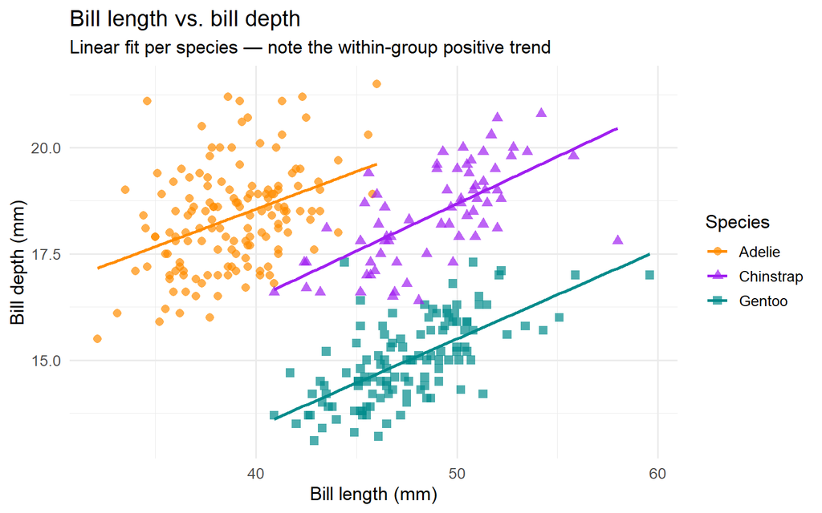

Figure 1: Bill length vs. bill depth coloured and fitted by species.

```r
ggplot(
  penguins_clean,
  aes(x = bill_length_mm, y = bill_depth_mm, colour = species, shape = species)
) +
  geom_point(alpha = 0.7, size = 2.5) +
  geom_smooth(method = "lm", se = FALSE, linewidth = 0.9) +
  scale_colour_manual(values = c("darkorange", "purple", "cyan4")) +
  scale_shape_manual(values = c(16, 17, 15)) +
  labs(
    title    = "Bill length vs. bill depth",
    subtitle = "Linear fit per species — note the within-group positive trend",
    x        = "Bill length (mm)",
    y        = "Bill depth (mm)",
    colour   = "Species", shape = "Species"
  ) +
  theme_minimal(base_size = 13)
```

### Flipper Length Distribution

The histogram in Figure 2 reveals that Gentoo penguins have notably longer flippers than Adélie or Chinstrap penguins, hinting at their larger overall body size.

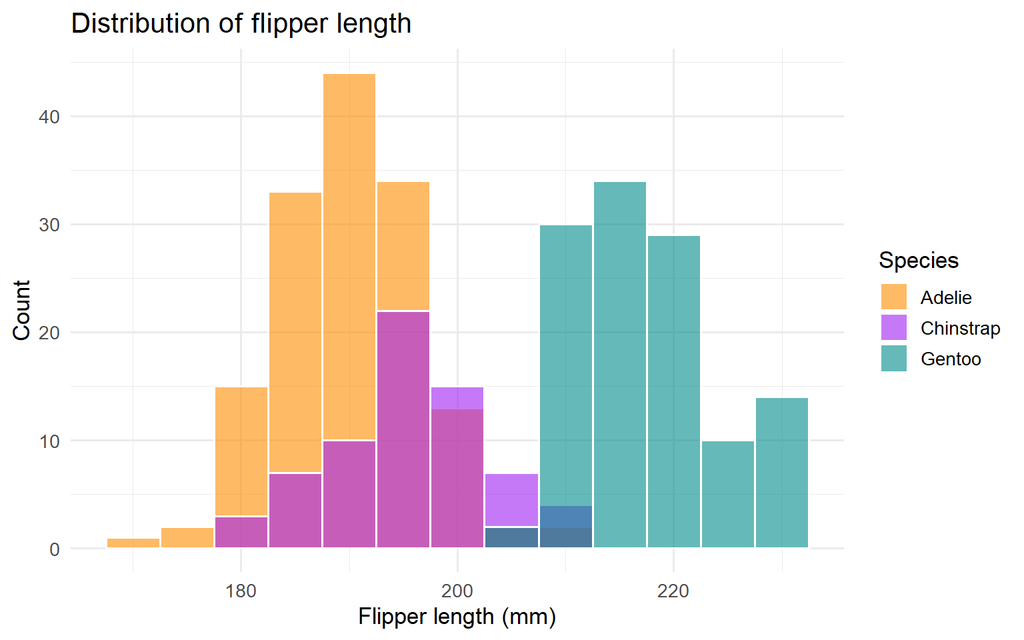

Figure 2: Overlaid histogram of flipper length for each species.

```r
ggplot(penguins_clean, aes(x = flipper_length_mm, fill = species)) +
  geom_histogram(alpha = 0.6, binwidth = 5, position = "identity", colour = "white") +
  scale_fill_manual(values = c("darkorange", "purple", "cyan4")) +
  labs(
    title = "Distribution of flipper length",
    x     = "Flipper length (mm)",
    y     = "Count",
    fill  = "Species"
  ) +
  theme_minimal(base_size = 13)
```

### Body Mass by Species and Sex

Figure 3 uses box plots to visualise body mass split by both species and sex. Sexual dimorphism is most pronounced in Gentoo penguins, where males are substantially heavier than females.

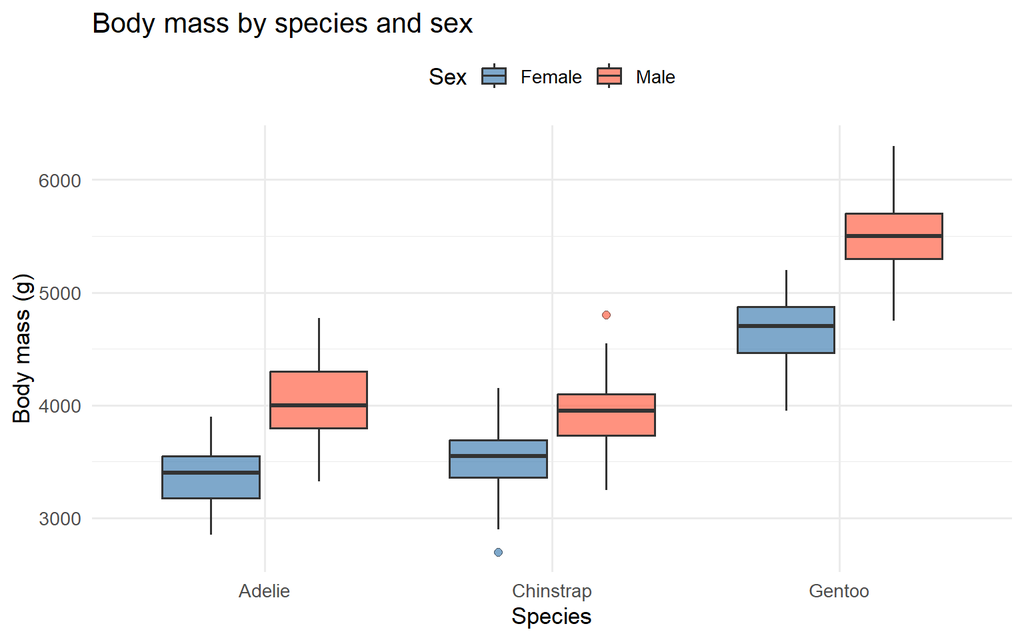

Figure 3: Box plots of body mass grouped by species and sex.

```r
ggplot(penguins_clean, aes(x = species, y = body_mass_g, fill = sex)) +
  geom_boxplot(alpha = 0.7, outlier.shape = 21, outlier.size = 2) +
  scale_fill_manual(values = c("steelblue", "tomato"), labels = c("Female", "Male")) +
  labs(
    title = "Body mass by species and sex",
    x     = "Species",
    y     = "Body mass (g)",
    fill  = "Sex"
  ) +
  theme_minimal(base_size = 13) +
  theme(legend.position = "top")
```

### Faceted Bill Dimensions by Island

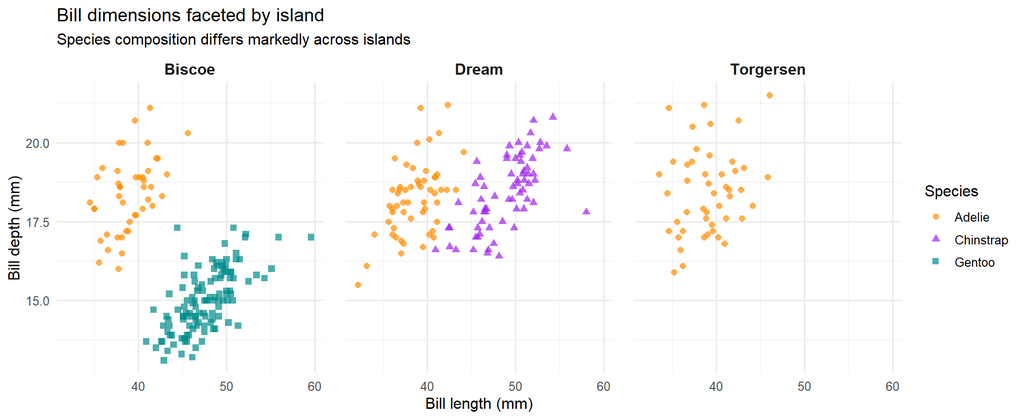

Figure 4: Bill length vs. depth faceted by island of observation.

```r
ggplot(
  penguins_clean,
  aes(x = bill_length_mm, y = bill_depth_mm, colour = species, shape = species)
) +
  geom_point(alpha = 0.7, size = 2) +
  facet_wrap(~island, nrow = 1) +
  scale_colour_manual(values = c("darkorange", "purple", "cyan4")) +
  scale_shape_manual(values = c(16, 17, 15)) +
  labs(
    title    = "Bill dimensions faceted by island",
    subtitle = "Species composition differs markedly across islands",
    x        = "Bill length (mm)",
    y        = "Bill depth (mm)",
    colour   = "Species", shape = "Species"
  ) +
  theme_minimal(base_size = 12) +
  theme(
    panel.spacing = unit(1.2, "lines"),
    strip.text    = element_text(face = "bold", size = 12)
  )
```

## Regression Analysis

We fit an ordinary least squares model predicting **body mass** from flipper length, bill dimensions, and species. This allows us to ask: *after controlling for species, how much of the variation in body mass is explained by morphometric measurements?*

$$\text{body mass}_i = \beta_0 + \beta_1\,\text{flipper} + \beta_2\,\text{bill length} + \beta_3\,\text{bill depth} + \beta_4\,\text{species} + \varepsilon_i$$

```r
model <- lm(
  body_mass_g ~ flipper_length_mm + bill_length_mm + bill_depth_mm + species,
  data = penguins_clean
)

tidy(model, conf.int = TRUE) |>
  mutate(across(where(is.numeric), \(x) round(x, 3))) |>
  rename(
    Term         = term,
    Estimate     = estimate,
    `Std. Error` = std.error,
    `t value`    = statistic,
    `p value`    = p.value,
    `CI Lower`   = conf.low,
    `CI Upper`   = conf.high
  ) |>
  kable()
```

Table 3: OLS regression results: body mass as outcome.

| Term | Estimate | Std. Error | t value | p value | CI Lower | CI Upper |
| --- | --- | --- | --- | --- | --- | --- |
| (Intercept) | -4282.080 | 497.832 | -8.601 | 0 | -5261.438 | -3302.723 |
| flipper_length_mm | 20.226 | 3.135 | 6.452 | 0 | 14.059 | 26.394 |
| bill_length_mm | 39.718 | 7.227 | 5.496 | 0 | 25.501 | 53.936 |
| bill_depth_mm | 141.771 | 19.163 | 7.398 | 0 | 104.072 | 179.470 |
| speciesChinstrap | -496.758 | 82.469 | -6.024 | 0 | -658.995 | -334.521 |
| speciesGentoo | 965.198 | 141.770 | 6.808 | 0 | 686.301 | 1244.096 |

The model explains **84.7%** of the variance in body mass (adjusted R² = 0.847), with a residual standard error of 315 g. Every additional millimetre of flipper length is associated with roughly 20.2 g of additional body mass, holding bill dimensions and species constant.

**ImportantCollinearity Note**

Flipper length, bill dimensions, and species are correlated predictors. The individual coefficient estimates should be interpreted cautiously — the model is best used for overall prediction rather than inferring causal effects of individual measurements.

## Summary

This notebook demonstrated a complete workflow with the Palmer Penguins dataset:

| Step | Output |
| --- | --- |
| Package management | Installed and loaded `tidyverse`, `palmerpenguins`, `broom` |
| Data cleaning | Dropped 11 rows with NAs |
| Scatter plot | Bill length vs. depth with per-species fits (Figure 1) |
| Histogram | Flipper length distributions overlaid by species (Figure 2) |
| Box plot | Body mass by species × sex (Figure 3) |
| Faceted scatter | Bill dimensions across islands (Figure 4) |
| Regression | Body mass ~ morphometrics + species (Adj. R² ≈ 0.85) |